# Mosquito Lumped Days Model

David L Smith

5/23/2019

## -

Here, we present a model for adult mosquito population and infection dynamics in the Ross-Macdonald style, but with a time step of $7$ days. A working assumption here is that the minimum EIP is greater than or equal to 8 days.

## Daily

### -

We want to build up a set of models for simulating mosquito population dynamics over a fixed $n$-day time step, where $n$ is on the order of 7 days. We start with the following set of equations to use as a reference. We will call this model `RMde`:

$$\begin{array}{rl}
M_{t+1} &= \Lambda_t + p M_t \\
Y_{0, t} &= f q \kappa_t (M_t - \sum_i Y_{i,t} - Z_t) \\
Y_{i+1, t+1} &= p Y_{i, t} \\
Z_{t+1} &= p Y_{n, t} + p Z_t \\
\end{array}$$

### par

```r
makeP.rm = function(p=.9, f=0.3, q=0.95, eip=16){
  ########################################################
  # p :: the probability of surviving one day
  # f :: the proportion of mosquitoes feeding each day
  # q :: the proportion of blood meal hosts who are human
  # eip :: the EIP (must be an integer)
  ########################################################
  list(p=p,f=f,q=q, eip=round(eip))
}
```

```r
P = makeP.rm()
```

### inits

```r
makeInit = function(P){
  # Y is a vector of length EIP
  with(P,list(M=1, Y=rep(0, eip), Z=0))
}
```

```r
MOS = makeInit(P)
```

### `RMde`

```r
RMde = function(lambda,kappa,t,MOS,P){with(c(MOS,P),{
  tt = t%%eip+1
  M = lambda + p*M
  Z = p*(Z + Y[tt])
  Y[tt] = (1-(1-kappa)^(f*q))*(M-sum(Y)-Z)*p^eip
  list(M=M,Y=Y,Z=Z)
})}
```

```r
RMde_run = function(lambda, kappa, P, MOS, tt=1:100){
  MM=c(MOS$M, MOS$Z)
  for(t in tt)
  {
    MOS = RMde(lambda, kappa, t, MOS, P)
    MM = rbind(MM, c(MOS$M, MOS$Z))
  }
  cbind(c(0,tt), MM)
}
```

```r
RMde_plot = function(MM){
  plot(MM[,1], MM[,2], type = "l", ylim = range(0,MM), ylab = expression(list (M, Z)), xlab = "Time (days)")
  lines(MM[,1], MM[,3])
}
```

### demo

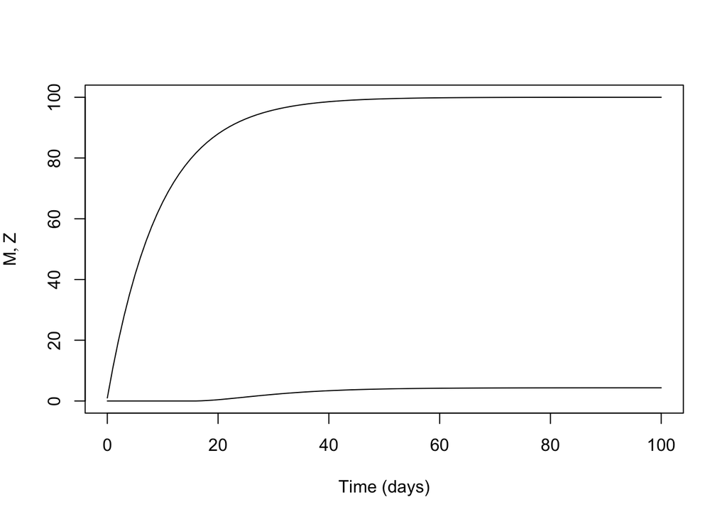

```r
MM1 = RMde_run(10, .1, P, MOS)
RMde_plot(MM1)
```